# Final Project Code

2026-05-11

## Code

### Source 1

For this first we are going to use a Kaggle data set with spotify music data

```r
library(tidyverse)
url <- "https://raw.githubusercontent.com/JZunaRepo/Spring27Projects/refs/heads/main/FinaProject/data.csv"

spotify_df <- read.csv(
  file = url
)
glimpse(spotify_df)
```

```
## Rows: 114,000
## Columns: 21
## $ X                <int> 0, 1, 2, 3, 4, 5, 6, 7, 8, 9, 10, 11, 12, 13, 14, 15,…
## $ track_id         <chr> "5SuOikwiRyPMVoIQDJUgSV", "4qPNDBW1i3p13qLCt0Ki3A", "…
## $ artists          <chr> "Gen Hoshino", "Ben Woodward", "Ingrid Michaelson;ZAY…
## $ album_name       <chr> "Comedy", "Ghost (Acoustic)", "To Begin Again", "Craz…
## $ track_name       <chr> "Comedy", "Ghost - Acoustic", "To Begin Again", "Can'…
## $ popularity       <int> 73, 55, 57, 71, 82, 58, 74, 80, 74, 56, 74, 69, 52, 6…
## $ duration_ms      <int> 230666, 149610, 210826, 201933, 198853, 214240, 22940…
## $ explicit         <chr> "False", "False", "False", "False", "False", "False",…
## $ danceability     <dbl> 0.676, 0.420, 0.438, 0.266, 0.618, 0.688, 0.407, 0.70…
## $ energy           <dbl> 0.4610, 0.1660, 0.3590, 0.0596, 0.4430, 0.4810, 0.147…
## $ key              <int> 1, 1, 0, 0, 2, 6, 2, 11, 0, 1, 8, 4, 7, 3, 2, 4, 2, 1…
## $ loudness         <dbl> -6.746, -17.235, -9.734, -18.515, -9.681, -8.807, -8.…
## $ mode             <int> 0, 1, 1, 1, 1, 1, 1, 1, 1, 1, 1, 1, 0, 1, 1, 1, 1, 0,…
## $ speechiness      <dbl> 0.1430, 0.0763, 0.0557, 0.0363, 0.0526, 0.1050, 0.035…
## $ acousticness     <dbl> 0.0322, 0.9240, 0.2100, 0.9050, 0.4690, 0.2890, 0.857…
## $ instrumentalness <dbl> 1.01e-06, 5.56e-06, 0.00e+00, 7.07e-05, 0.00e+00, 0.0…
## $ liveness         <dbl> 0.3580, 0.1010, 0.1170, 0.1320, 0.0829, 0.1890, 0.091…
## $ valence          <dbl> 0.7150, 0.2670, 0.1200, 0.1430, 0.1670, 0.6660, 0.076…
## $ tempo            <dbl> 87.917, 77.489, 76.332, 181.740, 119.949, 98.017, 141…
## $ time_signature   <int> 4, 4, 4, 3, 4, 4, 3, 4, 4, 4, 4, 3, 4, 4, 4, 3, 4, 4,…
## $ track_genre      <chr> "acoustic", "acoustic", "acoustic", "acoustic", "acou…
```

Exploring the dimensions and first rows of the data

```r
dim(spotify_df)
```

```
## [1] 114000     21
```

```r
head(spotify_df)
```

```
##   X               track_id                artists
## 1 0 5SuOikwiRyPMVoIQDJUgSV            Gen Hoshino
## 2 1 4qPNDBW1i3p13qLCt0Ki3A           Ben Woodward
## 3 2 1iJBSr7s7jYXzM8EGcbK5b Ingrid Michaelson;ZAYN
## 4 3 6lfxq3CG4xtTiEg7opyCyx           Kina Grannis
## 5 4 5vjLSffimiIP26QG5WcN2K       Chord Overstreet
## 6 5 01MVOl9KtVTNfFiBU9I7dc           Tyrone Wells
##                                               album_name
## 1                                                 Comedy
## 2                                       Ghost (Acoustic)
## 3                                         To Begin Again
## 4 Crazy Rich Asians (Original Motion Picture Soundtrack)
## 5                                                Hold On
## 6                                   Days I Will Remember
##                   track_name popularity duration_ms explicit danceability
```

[output cut: 20 more lines]

Checking for any blank values

```r
colSums(is.na(spotify_df))
```

```
##                X         track_id          artists       album_name
##                0                0                0                0
##       track_name       popularity      duration_ms         explicit
##                0                0                0                0
##     danceability           energy              key         loudness
##                0                0                0                0
##             mode      speechiness     acousticness instrumentalness
##                0                0                0                0
##         liveness          valence            tempo   time_signature
##                0                0                0                0
##      track_genre
##                0
```

Now checking how many genres are in the data set. The reason to do this is because this will make the clusters more meaningful and easier to interpret

```r
unique(spotify_df$track_genre)
```

```
##   [1] "acoustic"          "afrobeat"          "alt-rock"
##   [4] "alternative"       "ambient"           "anime"
##   [7] "black-metal"       "bluegrass"         "blues"
##  [10] "brazil"            "breakbeat"         "british"
##  [13] "cantopop"          "chicago-house"     "children"
##  [16] "chill"             "classical"         "club"
##  [19] "comedy"            "country"           "dance"
##  [22] "dancehall"         "death-metal"       "deep-house"
##  [25] "detroit-techno"    "disco"             "disney"
##  [28] "drum-and-bass"     "dub"               "dubstep"
##  [31] "edm"               "electro"           "electronic"
##  [34] "emo"               "folk"              "forro"
##  [37] "french"            "funk"              "garage"
##  [40] "german"            "gospel"            "goth"
##  [43] "grindcore"         "groove"            "grunge"
```

[output cut: 23 more lines]

Checking the distribution of tracks across genres

```r
spotify_df %>%
  count(track_genre, sort = TRUE)
```

```
##           track_genre    n
## 1            acoustic 1000
## 2            afrobeat 1000
## 3            alt-rock 1000
## 4         alternative 1000
## 5             ambient 1000
## 6               anime 1000
## 7         black-metal 1000
## 8           bluegrass 1000
## 9               blues 1000
## 10             brazil 1000
## 11          breakbeat 1000
## 12            british 1000
## 13           cantopop 1000
## 14      chicago-house 1000
```

[output cut: 100 more lines]

After exploring the genres and the tracks per genre let me to the decision to strip down some tracks. The full dataset is too large for k-means to run efficiently so I’m taking a stratified sample of 20 tracks per genre. This keeps representation balanced across all genres while keeping the dataset at a manageable size

```r
set.seed(42)

spotify_sample <- spotify_df %>%
  group_by(track_genre) %>%
  slice_sample(n = 20) %>%
  ungroup()

dim(spotify_sample)
```

```
## [1] 2280   21
```

Next, selecting only the numeric audio features for clustering. These are the same features Spotify uses internally tocharacterize and compare songs

```r
audio_features <- spotify_sample %>%
  select(track_name, artists, track_genre, danceability, energy,
         loudness, speechiness, acousticness, instrumentalness,
         liveness, valence, tempo)

glimpse(audio_features)
```

```
## Rows: 2,280
## Columns: 12
## $ track_name       <chr> "Nothing Like You and I", "Corinna - From \"The Natch…
## $ artists          <chr> "The Perishers", "Taj Mahal", "Zack Tabudlo", "Howie …
## $ track_genre      <chr> "acoustic", "acoustic", "acoustic", "acoustic", "acou…
## $ danceability     <dbl> 0.598, 0.621, 0.592, 0.636, 0.607, 0.647, 0.560, 0.59…
## $ energy           <dbl> 0.2910, 0.2940, 0.4900, 0.6250, 0.4730, 0.5670, 0.832…
## $ loudness         <dbl> -8.627, -13.468, -8.508, -7.895, -8.555, -8.971, -5.5…
## $ speechiness      <dbl> 0.0328, 0.1100, 0.0263, 0.0277, 0.0340, 0.0328, 0.035…
## $ acousticness     <dbl> 0.46600, 0.55800, 0.39500, 0.22200, 0.71200, 0.03180,…
## $ instrumentalness <dbl> 6.52e-05, 2.54e-05, 0.00e+00, 5.35e-05, 0.00e+00, 0.0…
## $ liveness         <dbl> 0.1200, 0.0946, 0.3330, 0.1190, 0.6600, 0.1330, 0.232…
## $ valence          <dbl> 0.3800, 0.7280, 0.4370, 0.3420, 0.5400, 0.3740, 0.802…
## $ tempo            <dbl> 123.978, 78.599, 99.994, 93.931, 119.698, 125.871, 10…
```

Before clustering I need to scale all the audio features so that each one contributes equally to the distance calculations k-means works by measuring how far apart songs are from each other and without scaling a feature like tempo would dominate simply because its numbers are much larger than something like danceability

```r
audio_scaled <- audio_features %>%
  select(danceability, energy, loudness, speechiness,
         acousticness, instrumentalness, liveness, valence, tempo) %>%
  scale()

round(colMeans(audio_scaled), 4)
```

```
##     danceability           energy         loudness      speechiness
##                0                0                0                0
##     acousticness instrumentalness         liveness          valence
##                0                0                0                0
##            tempo
##                0
```

```r
round(apply(audio_scaled, 2, sd), 4)
```

```
##     danceability           energy         loudness      speechiness
##                1                1                1                1
##     acousticness instrumentalness         liveness          valence
##                1                1                1                1
##            tempo
##                1
```

To find the optimal number of clusters I’m running k-means for k values from 1 to 10 and recording the total within cluster sum of squares (wss) for each one. The wss tells us how tightly packed the clusters are. A lower wss means songs within each cluster are more similar to each other which is exactly what we want

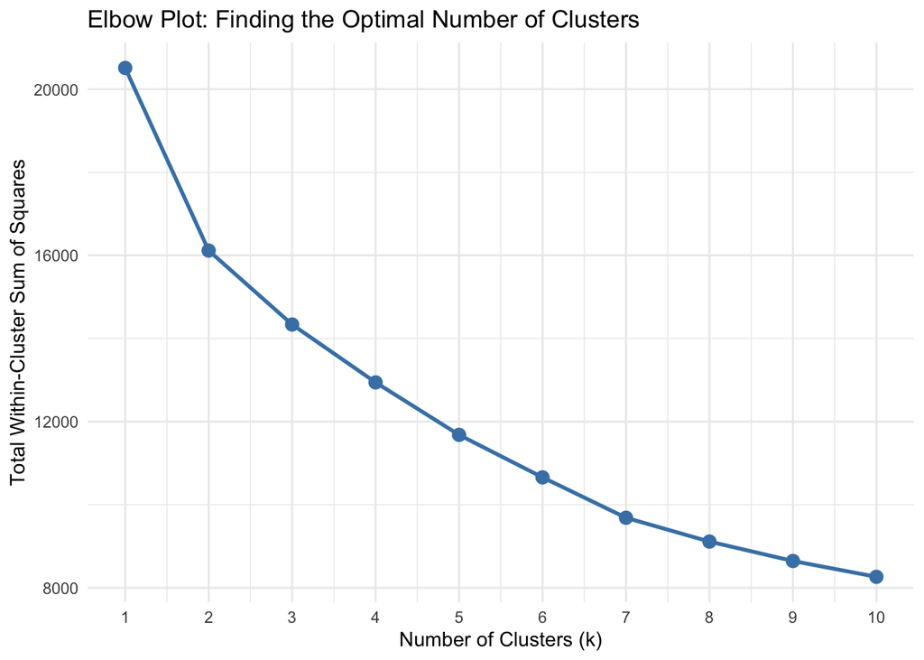

```r
set.seed(42)

wss <- map_dbl(1:10, function(k) {
  kmeans(audio_scaled, centers = k, nstart = 25)$tot.withinss
})

# Now let's plot the elbow curve
elbow_df <- tibble(k = 1:10, wss = wss)

ggplot(elbow_df, aes(x = k, y = wss)) +
  geom_line(color = "steelblue", linewidth = 1) +
  geom_point(size = 3, color = "steelblue") +
  scale_x_continuous(breaks = 1:10) +
  labs(
    title = "Elbow Plot: Finding the Optimal Number of Clusters",
    x = "Number of Clusters (k)",
    y = "Total Within-Cluster Sum of Squares"
  ) +
  theme_minimal()
```

```r
set.seed(42)

kmeans_result <- kmeans(audio_scaled, centers = 6, nstart = 25)
```